# Identifying MYC non-responders in Loven et al RNA-seq

# Description

This notebook details how MYC-resistant housekeeping genes, identified in Loven et al., are incorporated into RNA-seq normalization using DESeq2. Two DESeq2 models are generated:

1. Pairwise comparisons: Identifying genes differentially expressed between conditions.
2. Interaction term model (next notebook): Detecting genes whose response to SAE inhibitor treatment depends on MYC status.

## Load required libraries

```r
# load libraries
suppressMessages({
  library(tidyr)
  library(magrittr)
  library(ggplot2)
  library(dplyr)
  library(tibble)
  library(gprofiler2)
  library(stringr)
  library(DESeq2)
  library(ggrepel)
  library(ComplexHeatmap)
  library(limma)
  })
```

## Housekeeping Genes

```r
# Load housekeeping genes identified in the first notebook
ensg <- read.csv(file = "data/candidate_housekeeper_genes_from_Loven_RNAseq.csv")
housekeeping_genes <- ensg$target
rm(ensg)
```

## Sample Annotation and Raw Read Counts

```r
# sample annotation file
targets <- read.csv(file="data/targets.csv", row.names=1)

# gene annotation file and remove duplicate ensembl IDs
gene_anno <- read.csv(file="data/RNAseq_gene_annotations.csv")
gene_anno$GeneID <- str_replace(gene_anno$GeneID, pattern = ".[0-9]+$", replacement = "") # remove ensembl version number
gene_anno <- gene_anno[!duplicated(gene_anno$GeneID), ]
row.names(gene_anno) <- gene_anno$GeneID

# raw read counts
reads <- read.csv(file="data/reads.csv", row.names=1)
rownames(reads) <- str_replace(rownames(reads), pattern = ".[0-9]+$", replacement = "") # remove ensembl version number

# check target row names and reads column names match
cat("Are samples in the targets and read count data frames in the same order: ", identical(row.names(targets), colnames(reads)), "\n")
```

```
Are samples in the targets and read count data frames in the same order:  TRUE
```

```r
#read hallmark MYC targets gene lists
MYC1 <- read.csv(file="data/geneset_MYC_V1.csv")
myc1.lst <- list(MYC1$converted_alias)
```

## Deseq2 model with grouping factor (pair-wise comparisons)

```r
#create deseq data set
dds_grouped <- DESeqDataSetFromMatrix(countData = reads,
                              colData = targets,
                              design = ~Group)
# Extract counts for housekeeping genes
hk_reads <- counts(dds_grouped)[row.names(dds_grouped) %in% housekeeping_genes, ]

#remove genes whose combined expression is below 3
hk_reads_filtered <- hk_reads %>%
  as.data.frame() %>%
  mutate(Gene = row.names(.)) %>%  # Save row names as a new column called Gene
  rowwise() %>%
  filter(sum(c_across(-Gene)) >= 3) %>%  # Exclude the Gene column from the sum
  ungroup() %>%
  column_to_rownames(var = "Gene")  # Convert Gene column back to row names

# Extract ensembl IDs of housekeeping genes
housekeeping_genes <- row.names(hk_reads_filtered)

# Create index identifying rows of the reads stored in dds_grouped that correspond to house-keeping genes
isControl <- rownames(dds_grouped) %in% housekeeping_genes

# Estimate size factors using house-keeping genes as control genes
dds_grouped <- estimateSizeFactors(dds_grouped, controlGenes = isControl)

# Run DESeq2 analysis
dds_grouped <- DESeq(dds_grouped)
# check result names
resultsNames(dds_grouped)
```

```
[1] "Intercept"                     "Group_High_SAE2i_vs_High_DMSO" "Group_Low_DMSO_vs_High_DMSO"
[4] "Group_Low_SAE2i_vs_High_DMSO"
```

### PCA plot

```r
#variance stabilised transformed reads, with normalisation to MYC resistant house-keepers
vsd <- vst(dds_grouped)

#PCA
pcaData <- plotPCA(vsd, intgroup=c("Group"), returnData=TRUE)
```

```
using ntop=500 top features by variance
```

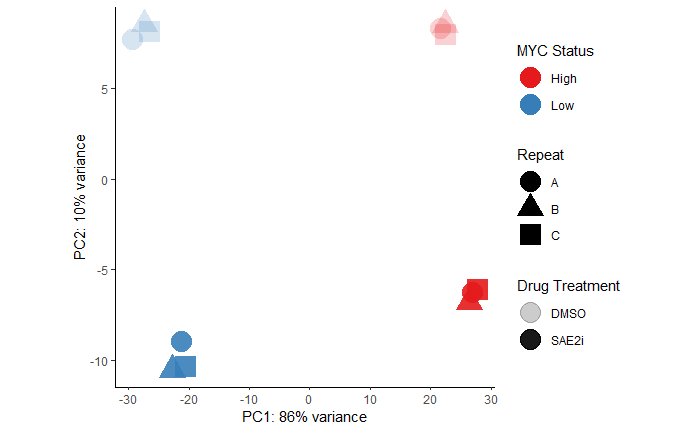

```r
write.csv(pcaData, file="output/PCA_data.csv")
percentVar <- round(100 * attr(pcaData, "percentVar"))

#plot with ggplot
PCA_plot <- ggplot(pcaData, aes(PC1, PC2, colour=targets$MYC)) +
  geom_point(size=7, aes(alpha=factor(targets$Treatment), shape=targets$Repeat)) +
  xlab(paste0("PC1: ",percentVar[1],"% variance")) +
  ylab(paste0("PC2: ",percentVar[2],"% variance")) +
  labs(shape="Repeat", alpha="Drug Treatment", colour = "MYC Status") +
  theme_classic() +
  scale_alpha_manual(values=c("DMSO"=0.2, "SAE2i"=0.9)) +
  scale_colour_brewer(palette="Set1") +
  scale_fill_brewer(palette="Set1") +
  theme(legend.position="right", aspect.ratio=1)

# Save the plot as PNG
ggsave("output/PCA_plot.png", PCA_plot, width = 6, height = 4, dpi = 300)

# Save the plot as PDF
ggsave("output/PCA_plot.pdf", PCA_plot, width = 6, height = 4)

# Print to notebook
print(PCA_plot)
```

### Deseq2 model with grouping factor (pair-wise comparisons)

#### 1. High MYC versus low MYC (DMSO samples only): differential expression summary

Identify genes with adjusted p value < 0.05 and summarise by table, annotate ensembl IDs with gene names and write output to CSV file.

```r
#extract specific condition of interest
res_grouped_MYC <- results(dds_grouped, contrast = c("Group", "High_DMSO", "Low_DMSO"), alpha=0.05)

# print a table to console
summary(res_grouped_MYC)
```

```
out of 29359 with nonzero total read count
adjusted p-value < 0.05
LFC > 0 (up)       : 9031, 31%
LFC < 0 (down)     : 1208, 4.1%
outliers [1]       : 1, 0.0034%
low counts [2]     : 10745, 37%
(mean count < 1)
[1] see 'cooksCutoff' argument of ?results
[2] see 'independentFiltering' argument of ?results
```

```r
#Add gene name annotations and write to CSV file
res_grouped_MYC_anno <- res_grouped_MYC %>%
  as.data.frame() %>%
  mutate(GeneID = rownames(.)) %>%
  right_join(gene_anno, by = "GeneID") %>%
  column_to_rownames(var = "GeneID") %T>%
  write.csv(file = "output/results_grouped_high_MYC_versus_low_MYC_DMSO_only.csv")
```

#### 1. High MYC versus low MYC (DMSO samples only): Visualise the results by volcano plot

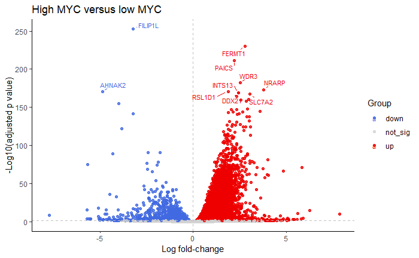

```r
#Colours for volcano plot points
cols <- c("down" = "RoyalBlue", "up" = "red2", "not_sig" = "lightgrey")

# Remove NAs and add factor for volcano plot up/down/not sig colouring
res_grouped_MYC_volc <- res_grouped_MYC_anno %>%
  na.omit() %>%
  mutate(Group = case_when(log2FoldChange <= 0 & padj <= 0.05 ~ "down",
                           log2FoldChange >= 0 &  padj <= 0.05 ~  "up",
                           padj >= 0.05 ~ "not_sig"))

# Labels for top ten most significant genes
res_grouped_MYC_labs <- res_grouped_MYC_volc %>%
  slice_min(padj, n = 10)

res_grouped_MYC_plot <- ggplot(data = res_grouped_MYC_volc, aes(log2FoldChange, -log10(padj), colour=Group)) +
  geom_point(alpha=0.8) +
  geom_hline(yintercept=1.301029996, colour="grey", linetype="dashed") +
  geom_vline(xintercept=0, colour="grey", linetype="dashed") +
  xlab(paste0("Log fold-change")) +
  ylab(paste0("-Log10(adjusted p value)")) +
  ggtitle("High MYC versus low MYC") +
  theme_classic()+
  scale_colour_manual(values= cols) +
  geom_text_repel(data = res_grouped_MYC_labs,
                  aes(label = GeneSymbol),
                  size = 3,
                  box.padding = 0.3,
                  point.padding = 0.5,
                  max.overlaps = 10,
                  min.segment.length = 0) +
  coord_cartesian(xlim = c(-max(abs(res_grouped_MYC_volc$log2FoldChange)),
                           max(abs(res_grouped_MYC_volc$log2FoldChange))))

# Save the plot as PNG
ggsave("output/volcano_grouped_high_MYC_versus_low_MYC_DMSO_only.png", res_grouped_MYC_plot, width = 6, height = 4, dpi = 300)

# Save the plot as PDF
ggsave("output/volcano_grouped_high_MYC_versus_low_MYC_DMSO_only.pdf", res_grouped_MYC_plot, width = 6, height = 4)

# Print to notebook
print(res_grouped_MYC_plot)
```

#### 1. High MYC versus low MYC (DMSO samples only): Hallmark MYC target gene enrichment and barcode plots

The pairwise comparisons performed using the grouping variable method are analysed for Hallmark MYC target gene enrichment

```r
# Convert ensembl ID position of MYC target genes to index
MYC1_ind <- ids2indices(myc1.lst, row.names(res_grouped_MYC_volc))

# Gene set enrichment test by cameraPR
cameraPR(res_grouped_MYC_volc$stat, index= MYC1_ind, use.ranks=T)
```

| NGenes | Direction | PValue |
| --- | --- | --- |
| 200 | Up | 2.338979e-29 |

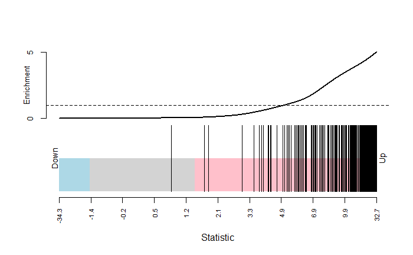

```r
# print barcode plot to console
barcodeplot(res_grouped_MYC_volc$stat, index = MYC1_ind[[1]])
```

### Deseq2 model with grouping factor (pair-wise comparisons):

#### 2. High MYC SAEi treatment versus DMSO: differential expression summary

```r
#extract specific condition of interest
res_grouped_SAE2i_high <- results(dds_grouped, contrast = c("Group", "High_SAE2i", "High_DMSO"), alpha = 0.05)

# print a table to console
summary(res_grouped_SAE2i_high)
```

```
out of 29359 with nonzero total read count
adjusted p-value < 0.05
LFC > 0 (up)       : 157, 0.53%
LFC < 0 (down)     : 213, 0.73%
outliers [1]       : 1, 0.0034%
low counts [2]     : 13969, 48%
(mean count < 5)
[1] see 'cooksCutoff' argument of ?results
[2] see 'independentFiltering' argument of ?results
```

```r
#Add gene name annotations and write to CSV file
res_grouped_SAE2i_high_anno <- res_grouped_SAE2i_high %>%
  as.data.frame() %>%
  mutate(GeneID = rownames(.)) %>%
  right_join(gene_anno, by = "GeneID") %>%
  column_to_rownames(var = "GeneID") %T>%
  write.csv(file = "output/results_grouped_high_MYC_SAEi_versus_DMSO.csv")
```

#### 2. High MYC SAEi treatment versus DMSO: visualise the results by volcano plot

```r
#Colours for volcano plot points
cols <- c("down" = "RoyalBlue", "up" = "red2", "not_sig" = "lightgrey")

# Remove NAs and add factor for volcano plot up/down/not sig colouring
res_grouped_SAE2i_high_volc <- res_grouped_SAE2i_high_anno %>%
  na.omit() %>%
  mutate(Group = case_when(log2FoldChange <= 0 & padj <= 0.05 ~ "down",
                           log2FoldChange >= 0 &  padj <= 0.05 ~  "up",
                           padj >= 0.05 ~ "not_sig"))

# Labels for top ten most significant genes
res_grouped_SAE2i_high_labs <- res_grouped_SAE2i_high_volc %>%
  slice_min(padj, n = 10)

res_grouped_SAE2i_high_plot <- ggplot(data = res_grouped_SAE2i_high_volc, aes(log2FoldChange, -log10(padj), colour=Group)) +
  geom_point(alpha=0.8) +
  geom_hline(yintercept=1.301029996, colour="grey", linetype="dashed") +
  geom_vline(xintercept=0, colour="grey", linetype="dashed") +
  xlab(paste0("Log fold-change")) +
  ylab(paste0("-Log10(adjusted p value)")) +
  ggtitle("High MYC SAE2i versus DMSO") +
  theme_classic()+
  scale_colour_manual(values= cols) +
  geom_text_repel(data = res_grouped_SAE2i_high_labs,
                  aes(label = GeneSymbol),
                  size = 3,
                  box.padding = 0.3,
                  point.padding = 0.5,
                  max.overlaps = 10,
                  min.segment.length = 0) +
  coord_cartesian(xlim = c(-max(abs(res_grouped_SAE2i_high_volc$log2FoldChange)),
                           max(abs(res_grouped_SAE2i_high_volc$log2FoldChange))))

# Print to notebook
print(res_grouped_SAE2i_high_plot)

# Save the plot as PNG
ggsave("output/volcano_grouped_high_MYC_SAEi_versus_DMSO.png", res_grouped_SAE2i_high_plot, width = 6, height = 4, dpi = 300)
```

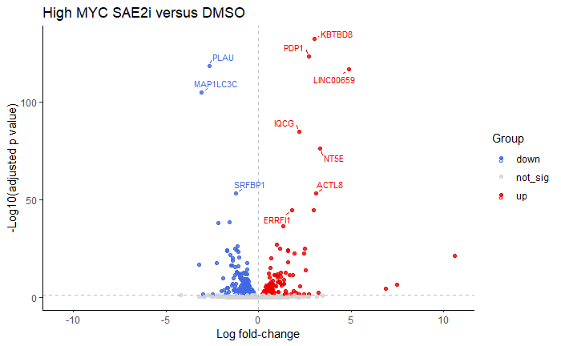

```r
# Save the plot as PDF
ggsave("output/volcano_grouped_high_MYC_SAEi_versus_DMSO.pdf", res_grouped_SAE2i_high_plot, width = 6, height = 4)
```

#### 2. High MYC SAEi treatment versus DMSO: Hallmark MYC target gene enrichment and barcode plots

The pairwise comparisons performed using the grouping variable method are analysed for Hallmark MYC target gene enrichment

```r
# Convert ensembl ID position of MYC target genes to index
MYC1_ind <- ids2indices(myc1.lst, row.names(res_grouped_SAE2i_high_volc))

# Gene set enrichment test by cameraPR
cameraPR(res_grouped_SAE2i_high_volc$stat, index= MYC1_ind, use.ranks=T)
```

| NGenes | Direction | PValue |
| --- | --- | --- |
| 200 | Up | 3.255351e-11 |

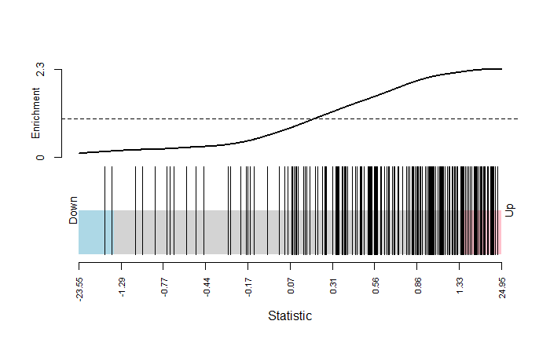

```r
# print barcode plot to console
barcodeplot(res_grouped_SAE2i_high_volc$stat, index = MYC1_ind[[1]])
```

### Deseq2 model with grouping factor (pair-wise comparisons):

#### 3. Low MYC - SAEi treatment versus DMSO: differential expression summary

```r
#extract specific condition of interest
res_grouped_SAE2i_low <- results(dds_grouped, contrast = c("Group", "Low_SAE2i", "Low_DMSO"), alpha = 0.05)

# print a table to console
summary(res_grouped_SAE2i_low)
```

```
out of 29359 with nonzero total read count
adjusted p-value < 0.05
LFC > 0 (up)       : 418, 1.4%
LFC < 0 (down)     : 462, 1.6%
outliers [1]       : 1, 0.0034%
low counts [2]     : 12894, 44%
(mean count < 3)
[1] see 'cooksCutoff' argument of ?results
[2] see 'independentFiltering' argument of ?results
```

```r
#Add gene name annotations and write to CSV file
res_grouped_SAE2i_low_anno <- res_grouped_SAE2i_low %>%
  as.data.frame() %>%
  mutate(GeneID = rownames(.)) %>%
  right_join(gene_anno, by = "GeneID") %>%
  column_to_rownames(var = "GeneID") %T>%
  write.csv(file = "output/results_grouped_low_MYC_SAEi_versus_DMSO.csv")
```

```r
#Colours for volcano plot points
cols <- c("down" = "RoyalBlue", "up" = "red2", "not_sig" = "lightgrey")

# Remove NAs and add factor for volcano plot up/down/not sig colouring
res_grouped_SAE2i_low_volc <- res_grouped_SAE2i_low_anno %>%
  na.omit() %>%
  mutate(Group = case_when(log2FoldChange <= 0 & padj <= 0.05 ~ "down",
                           log2FoldChange >= 0 &  padj <= 0.05 ~  "up",
                           padj >= 0.05 ~ "not_sig"))

# Labels for top ten most significant genes
res_grouped_SAE2i_low_labs <- res_grouped_SAE2i_low_volc %>%
  slice_min(padj, n = 10)

res_grouped_SAE2i_low_plot <- ggplot(data = res_grouped_SAE2i_low_volc, aes(log2FoldChange, -log10(padj), colour=Group)) +
  geom_point(alpha=0.8) +
  geom_hline(yintercept=1.301029996, colour="grey", linetype="dashed") +
  geom_vline(xintercept=0, colour="grey", linetype="dashed") +
  xlab(paste0("Log fold-change")) +
  ylab(paste0("-Log10(adjusted p value)")) +
  ggtitle("Low MYC - SAE2 versus DMSO") +
  theme_classic()+
  scale_colour_manual(values= cols) +
  geom_text_repel(data = res_grouped_SAE2i_low_labs,
                  aes(label = GeneSymbol),
                  size = 3,
                  box.padding = 0.3,
                  point.padding = 0.5,
                  max.overlaps = 10,
                  min.segment.length = 0) +
  coord_cartesian(xlim = c(-max(abs(res_grouped_SAE2i_low_volc$log2FoldChange)),
                           max(abs(res_grouped_SAE2i_low_volc$log2FoldChange))))

# Print to notebook
print(res_grouped_SAE2i_low_plot)

# Save the plot as PNG
ggsave("output/volcano_grouped_low_MYC_SAEi_versus_DMSO.png", res_grouped_SAE2i_low_plot, width = 6, height = 4, dpi = 300)
```

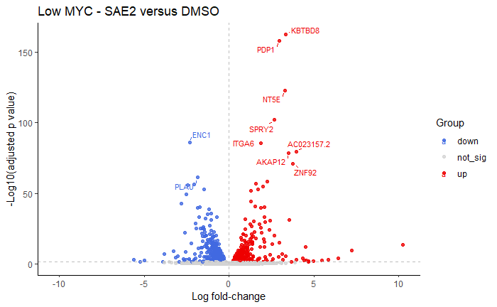

```r
# Save the plot as PDF
ggsave("output/volcano_grouped_low_MYC_SAEi_versus_DMSO.pdf", res_grouped_SAE2i_low_plot, width = 6, height = 4)
```

#### 3. Low MYC - SAEi treatment versus DMSO: Hallmark MYC target gene enrichment and barcode plots

The pairwise comparisons performed using the grouping variable method are analysed for Hallmark MYC target gene enrichment

```r
# Convert ensembl ID position of MYC target genes to index
MYC1_ind <- ids2indices(myc1.lst, row.names(res_grouped_SAE2i_low_volc))

# Gene set enrichment test by cameraPR
cameraPR(res_grouped_SAE2i_low_volc$stat, index= MYC1_ind, use.ranks=T)
```

| NGenes | Direction | PValue |
| --- | --- | --- |
| 200 | Up | 1.678839e-07 |

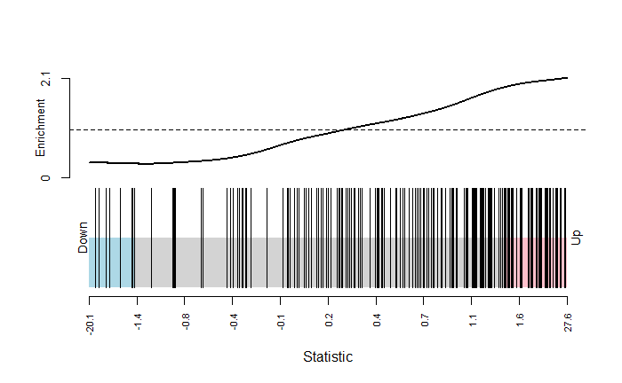

```r
# print barcode plot to console
barcodeplot(res_grouped_SAE2i_low_volc$stat, index = MYC1_ind[[1]])
```